# Principal response curves

Gavin Simpson

May 31, 2024

```r
library("vegan")
library("readr")
library("dplyr")
library("forcats")

spp <- read_csv(url("https://bit.ly/ohraz-spp")) %>%
    rename(label = "...1") %>%
    janitor::clean_names()
```

```r
molinia <- spp %>%
    select(label:molicaer)

spp <- spp %>%
    select(-molicaer) %>%
    tibble::column_to_rownames("label")

env <- read_csv(url("https://bit.ly/ohraz-env")) %>%
    rename(label = "...1") %>%
    mutate(across(c(mowing:removal, plotid), ~ factor(.x))) %>%
    tibble::column_to_rownames("label")
```

```
## ────────────────────────────────────────────────────────────────────── Delimiter: "," chr
## (5): ...1, mowing, fertilizer, removal, plotid dbl (1): year
## types or set `show_col_types = FALSE` to quiet this message.
```

We need to recode the variables to make this easier to understand for PRC

```r
env2 <- env %>%
mutate(mowed = fct_recode(mowing, mowed = "Yes", unmowed = "No"),
removed = fct_recode(removal, control = "No", removed = "Yes"),
fertilized = fct_recode(fertilizer, fertilized = "Yes", unfertilized = "No"),
removed = fct_relevel(removed, "control"),
treatment = fct_cross(removed, mowed, fertilized),
fyear = factor(year))
```

And we should log transform the species data as this is an RDA:

```r
log_spp <- log1p(spp)
```

The PRC can then be fitted using

```r
ohraz_prc <- prc(log_spp, env2$treatment, env2$fyear)
```

The permutation deisgn to use is

```r
h <- with(env2, how(plots = Plots(strata = plotid), nperm = 999))
```

And with this we can now test the first PRC (RDA) axis

```r
anova(ohraz_prc, permutations = h, first = TRUE)
```

```
## Permutation test for rda under reduced model
## Plots: plotid, plot permutation: none
## Permutation: free
## Number of permutations: 999
##
## Model: prc(response = log_spp, treatment = env2$treatment, time = env2$fyear)
##          Df Variance      F Pr(>F)
## RDA1      1   2.8841 11.151  0.001 ***
## Residual 64  16.5534
## ---
## Signif. codes:  0 '***' 0.001 '**' 0.01 '*' 0.05 '.' 0.1 ' ' 1
```

**Are the time structured effects of the treatment significant?**

We might also restrict the permutations within plots for time series

```r
h_time <- with(env2, how(plots = Plots(strata = plotid),
    within = Within(type = "series"), nperm = 999))
```

This gives a stricter test, especially if there is residual autocorrelation

```r
anova(ohraz_prc, permutations = h_time, first = TRUE)
```

```
## Permutation test for rda under reduced model
## Plots: plotid, plot permutation: none
## Permutation: series
## Number of permutations: 999
##
## Model: prc(response = log_spp, treatment = env2$treatment, time = env2$fyear)
##          Df Variance      F Pr(>F)
## RDA1      1   2.8841 11.151  0.001 ***
## Residual 64  16.5534
## ---
## Signif. codes:  0 '***' 0.001 '**' 0.01 '*' 0.05 '.' 0.1 ' ' 1
```

Does the effect remain after performing the stricter test?

Plot the PRC, without the species scores

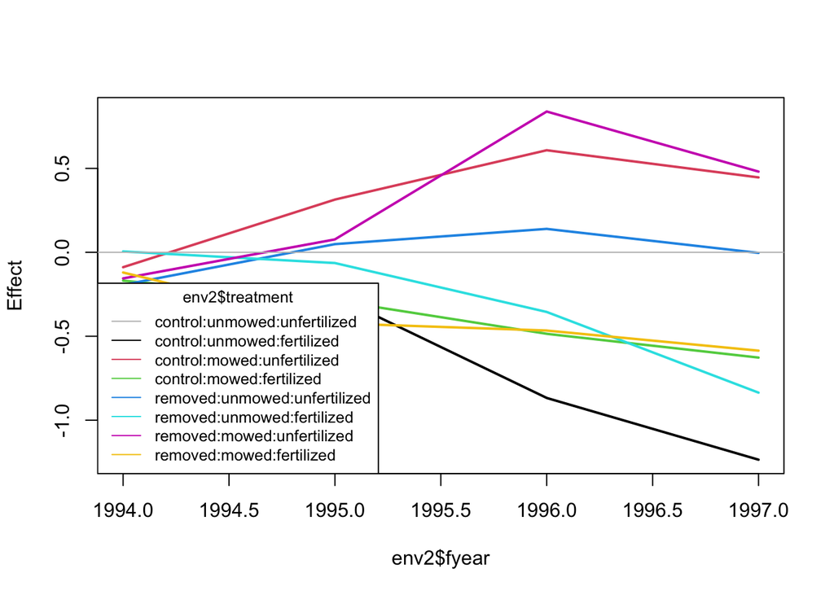

```r
plot(ohraz_prc, species = FALSE, legpos = "bottomleft", col = 1:8, lty = 1, lwd = 2)
```

**Which treatment levels/combinations lead to the largest changes in the species composition by the end of the experiment?**

We can plot the species scores on a separate plot, retaining only those species that have a fit greater than 5%

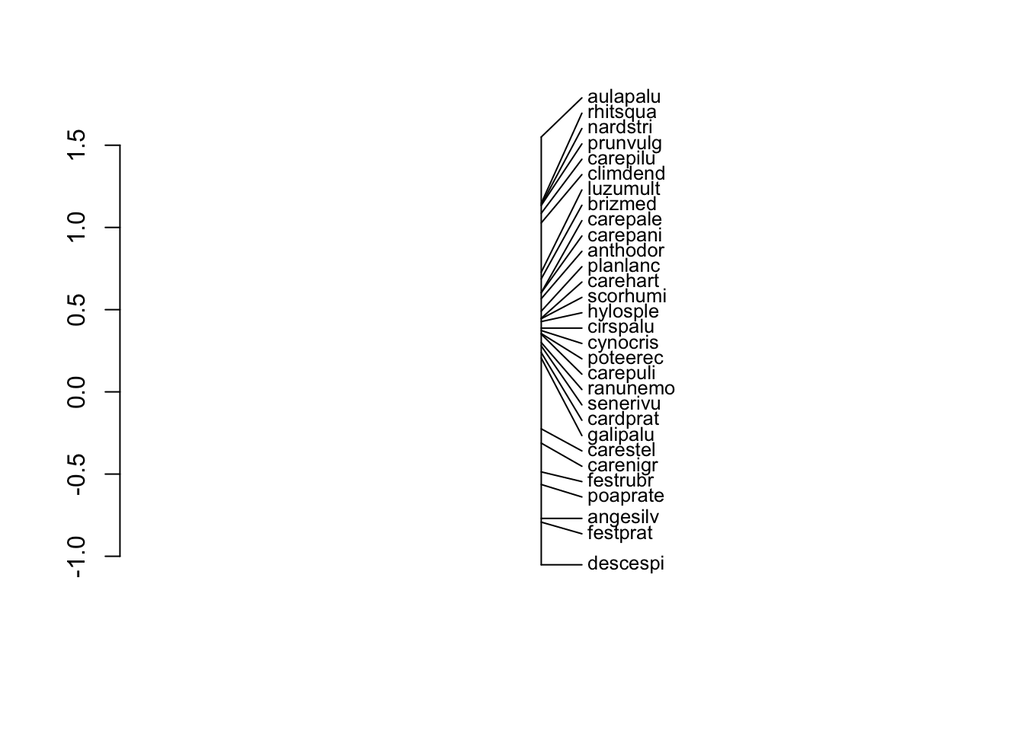

```r
fit <- goodness(ohraz_prc, display = "species", choices = 1, scaling = "symmetric")
scrs <- scores(ohraz_prc, display = "species", choices = 1, scaling = "symmetric")
linestack(scrs[fit > 0.05, , drop = FALSE])
axis(side = 2)
```

Suggest which species were affected most in the treatments that affected the composition the most.